# Notebook

## Preliminaries and plumbing:

The data collection is done by the included scripts. Not included is a file "SF.ini" with a section "[SF]" which has the key 'apikey' with a value set to (surprise!) the api key you want to use. - gmstub.py starts the level and saves the account and venue info to a config file - l6_dump_accts.py begins to trawl through orders, using the information leak in the 'cancel orders' API endpoint, to discover accounts trading on the venue; it then uses subprocesses to spin off instances of l6_snoop when it discovers a new and "active" account. - Each instance of l6_snoop.py uses the no-authentication-required websocket interface to grab all the executions on the discovered account, and throws them to a ZMQ intra-process queue. - l6_mon.py reads everything off from the queue and prints it to stdout - This notebook analyzes the data

I usually run it in two separate windows.

In the first one:

```
python gmstub.py start making_amends --save

python l6_dump_accts.py
```

And in the second:

```
stdbuf -o0 python l6_mon.py |tee rawdata.txt
```

Other notes: - All of this is done in an Ubuntu 14.04 VM with a more-or-less current Anaconda installation + libraries.  
- l6_snoop.py started life somewhere around level 3 as the websocket ping client example code from Twisted, and was modified from there. A brief inspection will no doubt show I know just enough about Twisted to be dangerous. - Honesty compels me to admit that this is the highlight reel, and doesn't show the many and varied dead ends I went down trying to figure out how to find the anomalous account. Was overthinking it quite a bit (a wavelet transform actually got me to the answer, but the regulator-friendly version of the evidence that doesn't involve Hilbert spaces is the one I went with).

```python
%matplotlib inline

import json, copy, pandas
import numpy as np
from dateutil import parser
from collections import defaultdict, Counter

# pull in the data, drop the extraneous info that my scripts stick in
print "loading data..."
alldata = [x for x in open('/home/ubuntu/stockfighter/rawdata.txt', 'r')]
alldata = [json.loads(''.join(x.split()[3:])) for x in alldata]
data = [x for x in alldata if 'order' in x and x['ok']==True]

print "getting prices..."
prices = [(x['order']['fills'][-1]['price'], parser.parse(x['order']['fills'][-1]['ts'])) for x in data]

# get the last version of the orders -- the one with the most fills
print "aggregating orders..."
orders = {}
executions = {}
repeats = 0

for x in data:
    to = copy.deepcopy(x['order'])
    if to['id'] in orders:
        # seen it before, only add if more fills in which case replace
        if len(to['fills']) > len(orders[to['id']]['fills']):
            orders[to['id']] = to
        else:repeats +=1
    else:
        # never seen it before, add it
        orders[to['id']]=to
print "Building dataframe..."

filldata = [{
    "orderId":x['order']['id'],
    "orderPrice":x['order']['price'],
    "orderQty":x['order']['originalQty'],
    "account":x['order']['account'],
    "orderTs":parser.parse(x['order']['ts']),
    "fillPrice":f['price'],
    "fillQty":f['qty'],
    "fillTs":parser.parse(f['ts']),
    "direction":x['order']['direction'],
    "signedQty":-f['qty'] if x['order']['direction']=='sell' else f['qty'],
    "otherId":x['standingId'] if x['standingId']!=x['order']['id'] else x['incomingId'],
    }
        for x in alldata for f in [x['order']['fills'][-1]]] #HAAAAAAAACK but mostly works
print len(filldata)
fills = pandas.DataFrame(filldata)
fills = fills.sort('fillTs')

fills['revenue']=fills['fillPrice']*fills['signedQty']

# build interesting or maybe useful information
X = pandas.DataFrame(orders.values())
X['signed_orders'] = [x if y=='buy' else -x for x,y in zip(X['originalQty'], X['direction'])]
X['signed_fills'] = [x if y=='buy' else -x for x,y in zip(X['totalFilled'], X['direction'])]
X['revenue']=[sum(o['price']*o['qty'] * (1 if z[1]['direction']=='sell' else -1) for o in z[1]['fills']) for z in X.iterrows() ]
X['ts'] = map(parser.parse, X['ts'])
X = X.sort("ts")
LAST = X['price'].tolist()[-1]
min_ts = min(X['ts'])
X['tradingDay'] = map(lambda x:(x - min_ts).total_seconds() // 5, X['ts'])

print "filtering out infrequent traders..."
high_cts = set(X[['account', 'originalQty']].groupby('account').aggregate(len).query("originalQty>100", engine="python").index.values)
X = X[X['account'].isin(high_cts)]

summ = X[['account', 'revenue', 'signed_fills', 'totalFilled']].groupby('account').sum().join(
    X[['account', 'originalQty']].groupby('account').aggregate(len).rename(
        columns={'originalQty':'orderCount'}
    )
).join(
    X[['account', 'revenue']].groupby('account').aggregate([min,max]).rename(
        columns = {('revenue', 'min'):"minRev", ('revenue', 'max'):'maxRev'}
    )
).join(
    X[['account', 'originalQty']].groupby('account').aggregate(np.mean).rename(
        columns={"originalQty":"OQ_mean"}
    )
)


summ['assets'] = LAST*summ['signed_fills']
summ['nav'] = summ['revenue'] + summ['assets']
summ['nav/fill'] = summ['nav']/summ['totalFilled']

print "Done!"
```

```
loading data...
getting prices...
aggregating orders...
Building dataframe...
22286
filtering out infrequent traders...
Done!
```

To start with, we look at some aggregate statistics of the data. There's generally three very large (institutional?) investors who usually take a beating, but reliably have a mean order size at least 10x the volume of everyone else. We are going to assume that our insider trader can't move that kind of volume.

If we sort by maximum revenue on a single order, and ignore the high-volume institutional traders, then we can usually see that one trader bubbles to the top. It might take a bit as some orders may fill over time, but by trading day 200 or so it's usually a dead ringer. The same trader also generally has a relatively low order count, but a slightly higher-than-normal mean "original quantity" per order. This is what you might expect from someone who's timing the market with inside information. Their single largest sale is also *much* larger sales (in terms of dollar amount) than any of the other traders, closer to the scale of an institutional trader than a market maker.

```python
summ.sort(('revenue', 'max'))[-10:]
```

| account | revenue | signed_fills | totalFilled | orderCount | (revenue, min) | (revenue, max) | OQ_mean | assets | nav | nav/fill |
| --- | --- | --- | --- | --- | --- | --- | --- | --- | --- | --- |
| BRB90293972 | 3366797 | 597 | 229841 | 345 | -6354552 | 7450172 | 668.568116 | 3323499 | 6690296 | 29.108366 |
| IAA49403006 | -1668370 | 2081 | 236549 | 363 | -6394015 | 7468008 | 653.969697 | 11584927 | 9916557 | 41.921788 |
| BC19578799 | 15416030 | -2227 | 238439 | 354 | -7371140 | 7569945 | 677.601695 | -12397709 | 3018321 | 12.658672 |
| EAA53440153 | -5120439 | 2014 | 239442 | 360 | -6807040 | 7629525 | 676.327778 | 11211938 | 6091499 | 25.440395 |
| FTB32129239 | 13653755 | -1112 | 235078 | 350 | -7726397 | 7929756 | 674.551429 | -6190504 | 7463251 | 31.747977 |
| EAA65819264 | -4499112 | 1973 | 232397 | 356 | -7086805 | 8241153 | 655.963483 | 10983691 | 6484579 | 27.903024 |
| EKB60692030 | 17967079 | -971 | 192413 | 178 | -27070364 | 51951012 | 1294.376404 | -5405557 | 12561522 | 65.284165 |
| BM16763445 | 253035016 | -65431 | 2153059 | 773 | -91370160 | 54231936 | 13190.126779 | -364254377 | -111219361 | -51.656439 |
| MH35021875 | 172254816 | -59608 | 2102272 | 735 | -84748146 | 64290640 | 14527.755102 | -331837736 | -159582920 | -75.909740 |
| PLB37635807 | -166327024 | 12631 | 1928389 | 726 | -82233180 | 83339960 | 13828.724518 | 70316777 | -96010247 | -49.787801 |

```python
non_institutional_accounts = summ[summ['OQ_mean']<10000].index.values
institutional_accounts = summ[summ['OQ_mean']>=10000].index.values
theaccused = summ[summ['OQ_mean']<10000].sort(('revenue', 'max')).index.values[-1]

print theaccused, "<--- this guy, go ruin his day"
```

```
EKB60692030 <--- this guy, go ruin his day
```

To take a closer look at this trader, and compare them to the other non-institutional accounts, we'll do some plotting. We exclude the 'institutional' accounts by filtering on total shares filled, and look at the accumulated position versus time, as well as the total dollar amount of all fills executed against each order.a

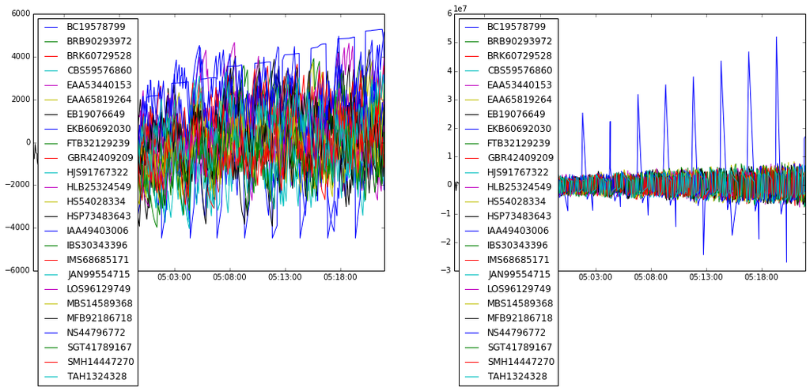

```python
import pylab
f=pylab.figure(figsize=(18,6))
pylab.subplot(121)
for acct in non_institutional_accounts:
    if summ[summ.index==acct]['totalFilled'][0]>500000:continue
    x = fills[fills['account']==acct]['fillTs']
    y = fills[fills['account']==acct]['signedQty'].cumsum()
    pylab.plot(x, y, label=acct)
pylab.legend(loc='best')

pylab.subplot(122)
for acct in non_institutional_accounts:
    if summ[summ.index==acct]['totalFilled'][0]>500000:continue
    x = X[X['account']==acct]['ts']
    y = X[X['account']==acct]['revenue']
    pylab.plot(x, y, label=acct)
pylab.legend(loc='best')
```

Sorry about the legends. But they don't obscure the main point: we can split the active non-institutional accounts into two groups: - Market makers: - position versus time has a sawtooth pattern; they're constantly moving shares - the absolute dollar amount of any given transaction is relatively small - Our suspect: - Has a position versus time trajectory with a much lower frequency pattern; they will go through long periods where they really only fill orders in one direction - Has a handful of orders with extremely large dollar amounts

It's important to note that we're missing trades at the beginning, so the absolute value of the position is unreliable; if we missed a lot of buys at the beginning, then we'll think they're going short when they're really just closing a position, and similarly for sells, but the relative change in position is informative. While the market makers all have a position over time with a sawtooth pattern, the suspect account appears comfortable with holding a steady position for long periods of time inbetween dropping large orders into the market.

While it's hard to say whether our suspect is shorting then covering, or building a position then selling off, they are definitely making extremely large moves with a regular pattern.

```
(-100, 100)
```

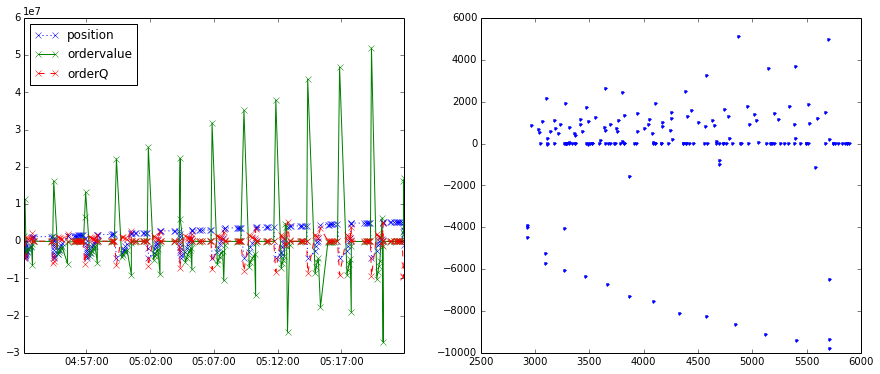

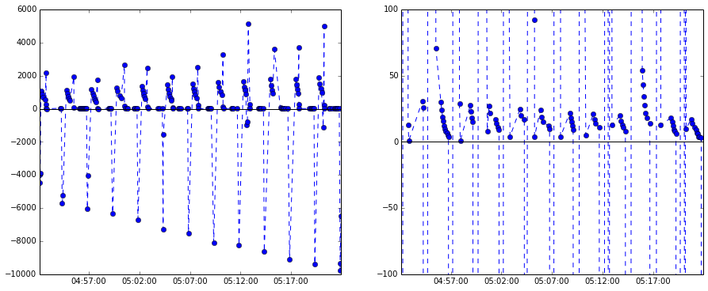

```python
f = pylab.figure(figsize=(15,6))
pylab.subplot(1,2,1)
x = fills[fills['account']==theaccused]['fillTs']
y = fills[fills['account']==theaccused]['signedQty'].cumsum()*1000
pylab.plot(x, y, ':x', label="position")

x = X[X['account']==theaccused]['ts']
y = X[X['account']==theaccused]['revenue']
pylab.plot(x, y, '-x', label="ordervalue")

x = X[X['account']==theaccused]['ts']
y = X[X['account']==theaccused]['signed_orders']*1000
pylab.plot(x, y, '--x', label="orderQ")

pylab.legend(loc='best')

pylab.subplot(1,2,2)
x = X[X['account']==theaccused]['price']
y = X[X['account']==theaccused]['signed_orders']
pylab.plot(x,y,'.')

pylab.figure(figsize=(15,6))
pylab.subplot(1,2,1)
x = X[X['account']==theaccused]['ts']
y = X[X['account']==theaccused]['signed_orders']
pylab.plot(x, y, '--o', label="orderQ")
pylab.plot([min(x), max(x)], [0,0], '-k')
pylab.subplot(1,2,2)
x = X[X['account']==theaccused]['ts']
y = X[X['account']==theaccused]['signed_orders']
pylab.plot(x, y, '--o', label="orderQ")
pylab.plot([min(x), max(x)], [0,0], '-k')
pylab.ylim(-100, 100)
```

I've rescaled some values to be more visible, and the caveats about data missing at the start still hold, but the pattern is very visible, particularly in the first few trading 'months'. If you look at signed quantity (sells are negative) vs price in the upper right, it becomes even more obvious that there are outlying orders. The lower left plot -- signed order quantity versus time -- helps demonstrate the pattern. The bottom right figure is zoomed in on the y-axis to allow for the visualization of smaller orders.

For reference, three (psuedo-) random non-institutional accounts have the same data plotted below. Note the absence of the outlying orders, and the rarity of runs of consecutive buys or sells.

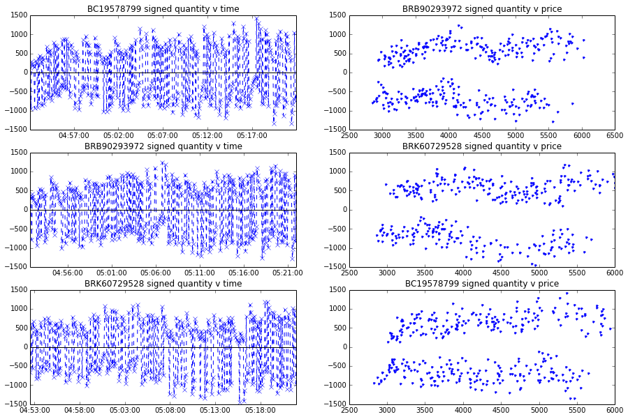

```python
other_accounts = [a for a in non_institutional_accounts if a != theaccused][:3]

P = np.random.permutation(len(other_accounts))

pylab.figure(figsize=(15,10))
for i in range(3):
    pylab.subplot(3,2,2*i)
    x = X[X['account']==other_accounts[P[i]]]['price']
    y = X[X['account']==other_accounts[P[i]]]['signed_orders']
    pylab.plot(x,y,'.')
    pylab.title(other_accounts[i]+ " signed quantity v price")
    pylab.subplot(3,2,2*i+1)
    x = X[X['account']==other_accounts[P[i]]]['ts']
    y = X[X['account']==other_accounts[P[i]]]['signed_orders']
    pylab.plot(x, y, '--x', label="orderQ")
    pylab.plot([min(x), max(x)], [0,0], '-k')
    pylab.title(other_accounts[i]+" signed quantity v time")
```

Just if you wanted to pick a particular day to go sweat him a bit.

```python
accused_data = X[X['account']==theaccused][['direction', 'id', 'signed_orders','price', 'tradingDay']]
accused_data[accused_data['signed_orders']>np.percentile(accused_data['signed_orders'], 90)]
```

|  | direction | id | signed_orders | price | tradingDay |
| --- | --- | --- | --- | --- | --- |
| 860 | buy | 7015 | 2196 | 3099 | 94 |
| 1924 | buy | 9348 | 1920 | 3280 | 128 |
| 2980 | buy | 11447 | 1729 | 3473 | 156 |
| 3977 | buy | 13631 | 2638 | 3647 | 188 |
| 4861 | buy | 15503 | 2442 | 3803 | 215 |
| 5829 | buy | 17547 | 1935 | 4106 | 245 |
| 6681 | buy | 19307 | 1526 | 4255 | 269 |
| 6850 | buy | 19687 | 2528 | 4377 | 275 |
| 7631 | buy | 21376 | 1615 | 4439 | 299 |
| 7791 | buy | 21740 | 3294 | 4574 | 305 |
| 8585 | buy | 23394 | 1634 | 4736 | 329 |
| 8748 | buy | 23755 | 5156 | 4873 | 335 |
| 9643 | buy | 25613 | 1784 | 4955 | 361 |
| 9808 | buy | 25996 | 3601 | 5141 | 366 |
| 10592 | buy | 27727 | 1782 | 5336 | 391 |
| 10721 | buy | 27990 | 3689 | 5397 | 395 |
| 11487 | buy | 29635 | 1889 | 5513 | 419 |
| 11688 | buy | 30043 | 4978 | 5694 | 425 |

```python
accused_data[accused_data['signed_orders']<np.percentile(accused_data['signed_orders'], 5)]
```

|  | direction | id | signed_orders | price | tradingDay |
| --- | --- | --- | --- | --- | --- |
| 5506 | sell | 16838 | -7305 | 3870 | 234 |
| 6516 | sell | 18957 | -7505 | 4089 | 264 |
| 7469 | sell | 21012 | -8098 | 4323 | 294 |
| 8433 | sell | 23044 | -8237 | 4577 | 324 |
| 9385 | sell | 25106 | -8638 | 4839 | 354 |
| 10397 | sell | 27253 | -9083 | 5120 | 384 |
| 11358 | sell | 29326 | -9391 | 5400 | 414 |
| 12298 | sell | 31370 | -9758 | 5706 | 444 |
| 12314 | sell | 31394 | -9327 | 5706 | 444 |

# Conclusion

Such as it is.

```python
print "The insider account is", theaccused
```

```
The insider account is EKB60692030
```

The supporting evidence is: 1. Their anomalously large orders relative to the rest of their orders 2. The fact that these orders come in at extremely regular intervals 3. The fact that the pattern of buy-sell orders contains long sequences of buy orders, while other noninstitutional accounts have a more random-appearing distribution.

Whoever runs this account either has a magnificent disdain for risk/more money than sense and therefore sees no problem with accumulating uncovered positions worth hundreds of thousands of dollars, or he knows something the rest of the market doesn't.